# Debian9 外接硬碟

teuton

7/19/2021

# 1 Debian9 安裝

使用容量超過 10 GB 的隨身碟，將其格式化並做成 Debian9 開機用的隨身碟

## 1.1 前置作業

[點擊這裡](https://cdimage.debian.org/cdimage/archive/9.13.0/amd64/iso-dvd/debian-9.13.0-amd64-DVD-1.iso)下載 Debian9 amd64 的 iso 檔

如果有必要，就將外接硬碟的一部份切割成 exfat 格式，作為 Debian9 辨識的格式化區域和安裝位置

## 1.2 製作 Debian 開機隨身碟

移除外接硬碟，插入隨身碟，執行指令 `diskutil list` 並尋找 external, physical 的磁區–你的隨身碟，如圖 1.1 所示

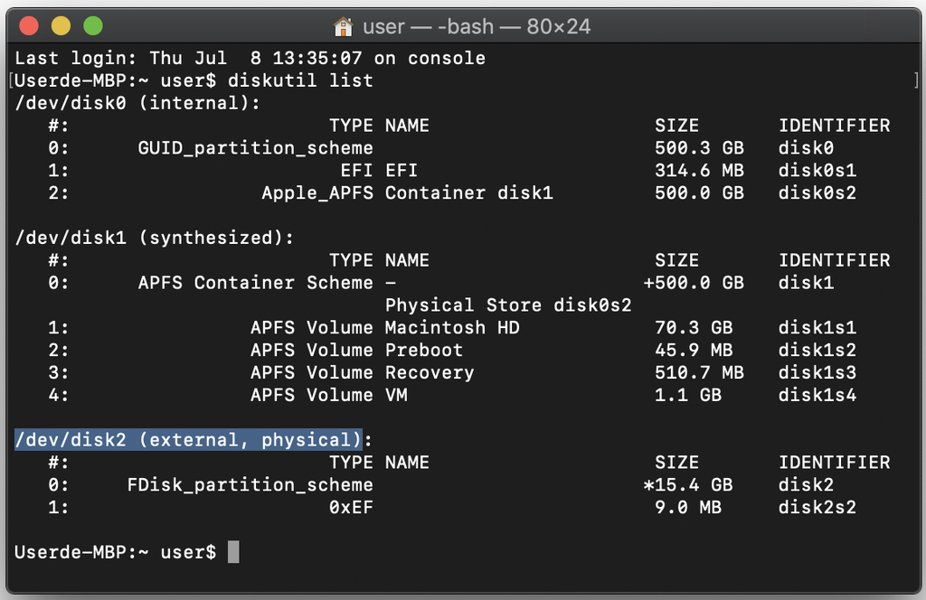

Figure 1.1: 隨身碟位置

以此為基準，依序輸入以下三個指令

- `diskutil unmountDisk /dev/disk2` 卸載隨身碟
- `sudo dd if=<Debian.iso 位置> of=/dev/disk2` 將映像檔燒錄至隨身碟內，這個過程需要半小時到一小時
- `diskutil eject /dev/disk2` 退出隨身碟

如果燒錄隨身碟出現錯誤訊息，就改為在還原模式下的終端機進行操作(開機時按住 command + R，在上方的選單可以找到終端機，此時不需要 sudo)

## 1.3 進行系統安裝

將電腦關機，插入外接硬碟、開機隨身碟、USB 鍵盤和 USB 滑鼠，按住 option 鍵開機，選擇 EFI Boot，選擇 graphical install，依照安裝流程進行設定，安裝過程中幾點提醒

### 1.3.1 磁碟分割

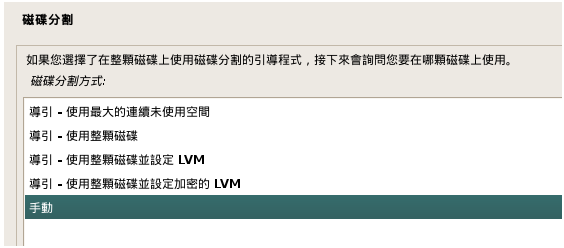

Figure 1.2: 選擇手動分割磁碟

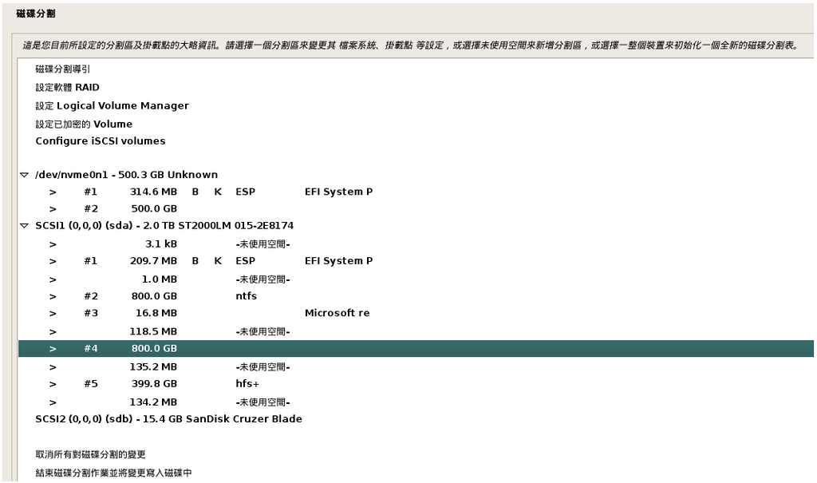

Figure 1.3: 選擇安裝磁碟區

由於 Debian9 還無法認得此磁碟區格式，所以先刪除它，如圖 1.4所示

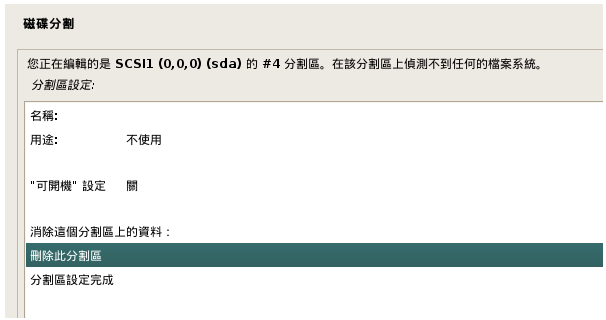

Figure 1.4: 格式化指定磁碟區

清出此安裝空間後，就可使用導引分割來自動切割成系統需要的磁碟區，如圖 1.5所示，看到指定安裝磁區顯示為**未使用空間**後回到導引頁面

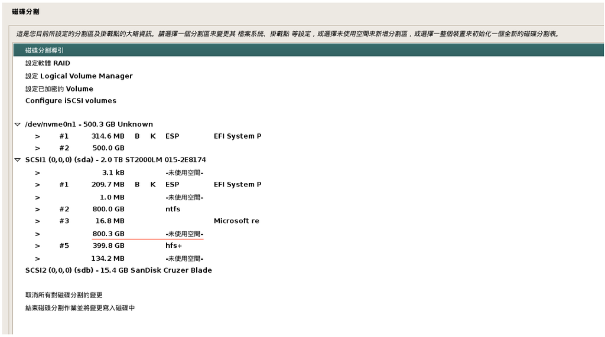

Figure 1.5: 確認安裝磁碟區

使用最大的連續未使用空間，這通常會使用你剛才清出來的位置，如圖 1.6所示

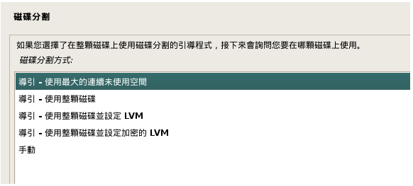

Figure 1.6: 選擇導引切割

選擇第一個磁碟分割方式，如圖 1.7所示

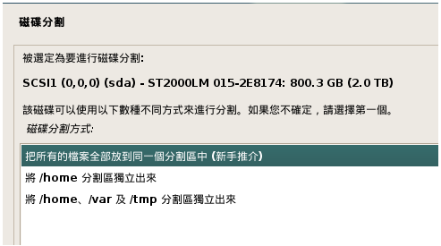

Figure 1.7: 選擇分割方式

系統會將安裝區域分成二塊，/ 和 swap，如圖 1.8所示，確認無誤後儲存變更

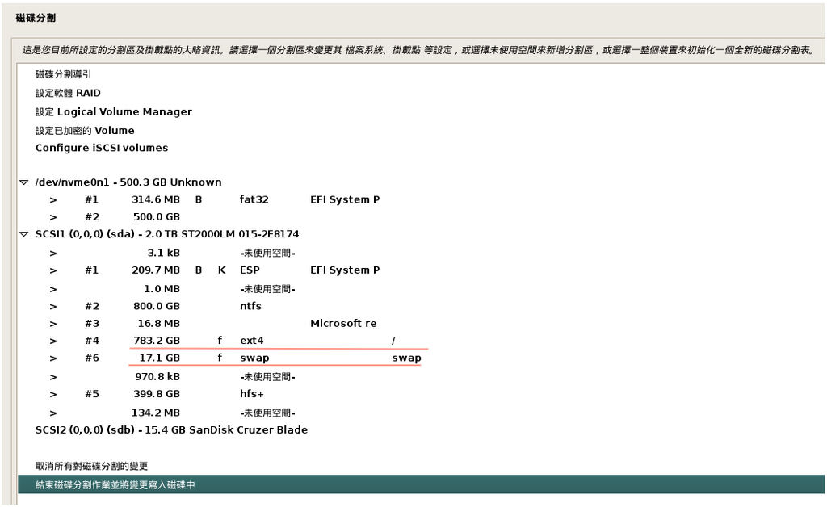

Figure 1.8: 確認磁碟分割

完成磁碟分割，如圖 1.9所示

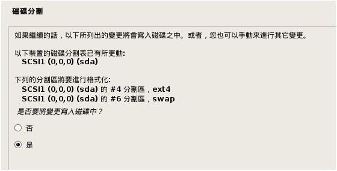

Figure 1.9: 完成磁碟分割

### 1.3.2 選擇軟體

本例指定使用 GNOME 桌面環境，如圖 1.10所示

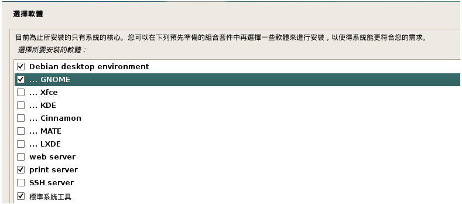

Figure 1.10: 選擇桌面環境

### 1.3.3 選擇鏡像站

如果沒有網路連線，或是基本驅動程式無法驅動你的網卡，你可以先跳過此步驟，繼續進行有限的安裝，安裝完成後參考第1.4.3節的做法設置鏡像站

在網路連線存在的情況下，你可以加入鏡像站來進行較完整的安裝，如圖 1.11所示，選擇否後繼續

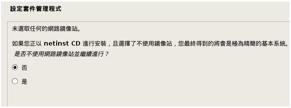

選擇鏡像站，台灣區域推薦 ftp.tw.debian.org，如圖 1.12所示

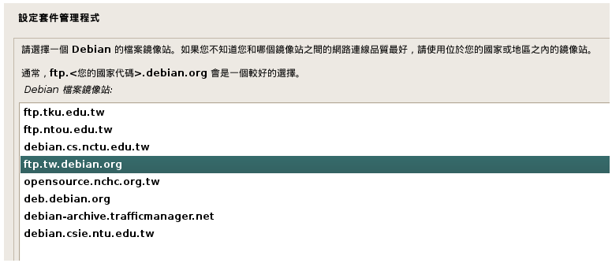

Figure 1.12: 選擇鏡像站

## 1.4 安裝基本驅動程式

### 1.4.1 以 nomodeset 模式啟動 Debian9

在完成 Debian 安裝後，由於螢幕的驅動程式仍不存在，正常啟動 Debian 是行不通的，所以要改用 nomodeset 模式啟動

- 在選單的 Debian 選項按下 **e** 鍵進入開機設定
- 找到 `linux /boot/vmlinuz-4.9.0... ro quiet`指令，將其改為 `linux /boot/vmlinuz-4.9.0... ro` **nomodeset** `quiet`
- 按下 F10，就能以 nomodeset 模式啟動 Debian9

### 1.4.2 Broadcom BCM43602 802.11ac [14e4:43ba] 驅動程式

使用以下指令確認網卡韌體

```r
lspci | grep Net
```

如圖 1.13 所示，本例使用 Broadcom BCM43602 網卡，一開始 Debian9 不支援此類型，所以需要驅動程式來連線至網路，若你的網卡不是這一類型，跳過此小節

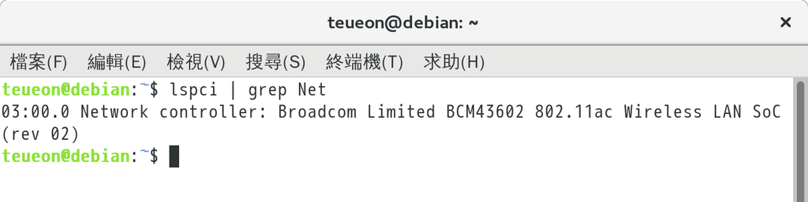

Figure 1.13: 網路韌體裝置

先在其他有網路的地方下載[驅動安裝檔](http://ftp.tw.debian.org/debian/pool/non-free/f/firmware-nonfree/firmware-brcm80211_20190114-2_all.deb)以及[驅動文字檔](https://bugzilla.kernel.org/attachment.cgi?id=285753)，然後傳輸到 Debian 內

使用以下指令安裝 `firmware-brcm80211_20190114-2_all.deb·` 驅動安裝檔

```r
sudo dpkg -i <firmware-brcm80211_20190114-2_all.deb 檔位置>
```

安裝完成後，將 `brcmfmac43602-pcie.txt` 驅動文字檔放置在 `/lib/firmware/brcm/` 內，輸入以下指令找到你的位址

```r
ip addr | grep ether
```

複製你的位址，如圖 1.14 所示

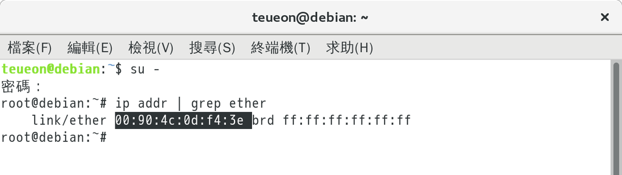

Figure 1.14: 尋找 MAC 位址

修改剛才放置的文字檔的三個參數，如圖 1.15 所示

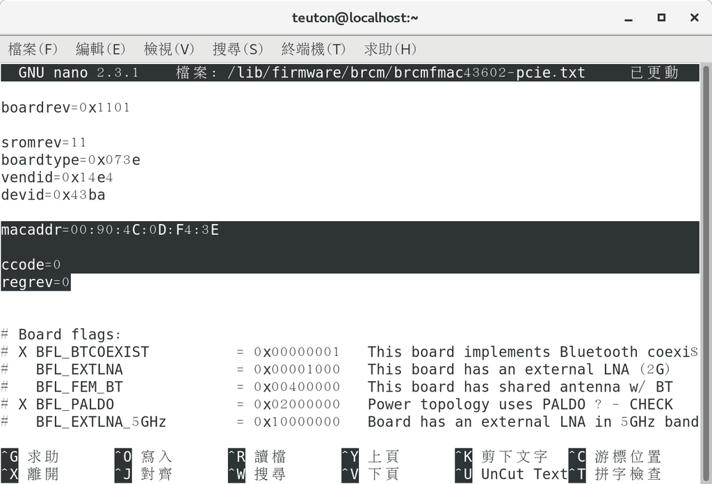

Figure 1.15: brcm43602 設定

- macaddr=00:90:4c:0d:f4:3e (你的 MAC 位址)
- ccode=0
- regrev=0

重新開機，現在你應該可以連線至網路了

注意:在完成螢幕韌體驅動程式的安裝以前，你必須以 nomodeset 模式進入 debian

### 1.4.3 設定鏡像站

如果系統安裝過程有設置鏡像站，你可跳過此步驟

修改 `/etc/apt/sources.list` 檔，將第五行 `deb cdrom ...` 前方加入 # 註解掉，然後加入 `deb http://ftp.tw.debian.org/debian/ stretch main contrib non-free` 和 `deb-src http://ftp.tw.debian.org/debian/ stretch main contrib non-free` 二行，如圖 1.16 所示，然後儲存檔案

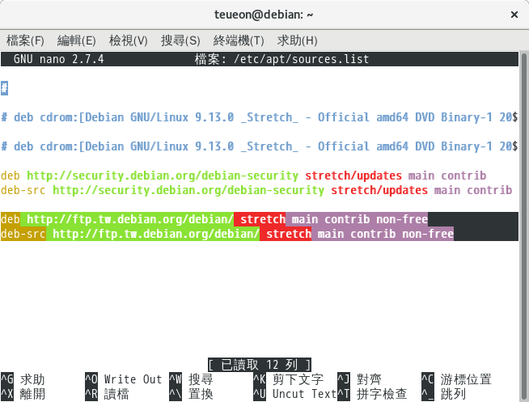

Figure 1.16: 鏡像站設定

### 1.4.4 安裝螢幕韌體驅動程式

在終端機執行以下指令

```r
# 更新套件清單
apt-get update

# 安裝螢幕韌體驅動程式
apt-get install firmware-amd-graphics
```

完成後重新開機，正常啟動 debian 就不會有問題，而且螢幕解析度也會比較正常

# 2 手動編譯核心

## 2.1 前置作業

用指令 `su -` 成為 root 使用者，新增核心資料夾，然後切換至此資料夾內

```r
mkdir /usr/src/kernels
cd /usr/src/kernels
```

使用以下指令得到內核資料夾，然後下載編譯核心所需要使用的其他工具套件，本例使用 4.19.195 版本

```r
# 下載內核
wget https://cdn.kernel.org/pub/linux/kernel/v4.x/linux-4.19.195.tar.xz

# 第一次解壓縮，得到壓縮檔
unxz -v linux-4.19.195.tar.xz

# 第二次解壓縮，得到資料夾
tar xvf linux-4.19.195.tar

# 移動至核心資料夾內
cd linux-4.19.195

# 將現有組態檔複製於此處備用
cp -v /boot/config-$(uname -r) .config
```

## 2.2 安裝必要套件

使用指令安裝必要套件

```r
# 安裝編譯核心套件
apt-get install make gcc libncurses-dev bison flex libelf-dev libssl-dev
```

## 2.3 選擇編譯核心模組

使用以下指令進入核心組態設定

```r
make menuconfig
```

新增 Device Drivers -> SPI support -> PXA2xx SSP SPI master 模組，此模組為驅動 mac 鍵盤的必要模組，如圖 2.1 所示，完成後儲存成 `.config` 檔

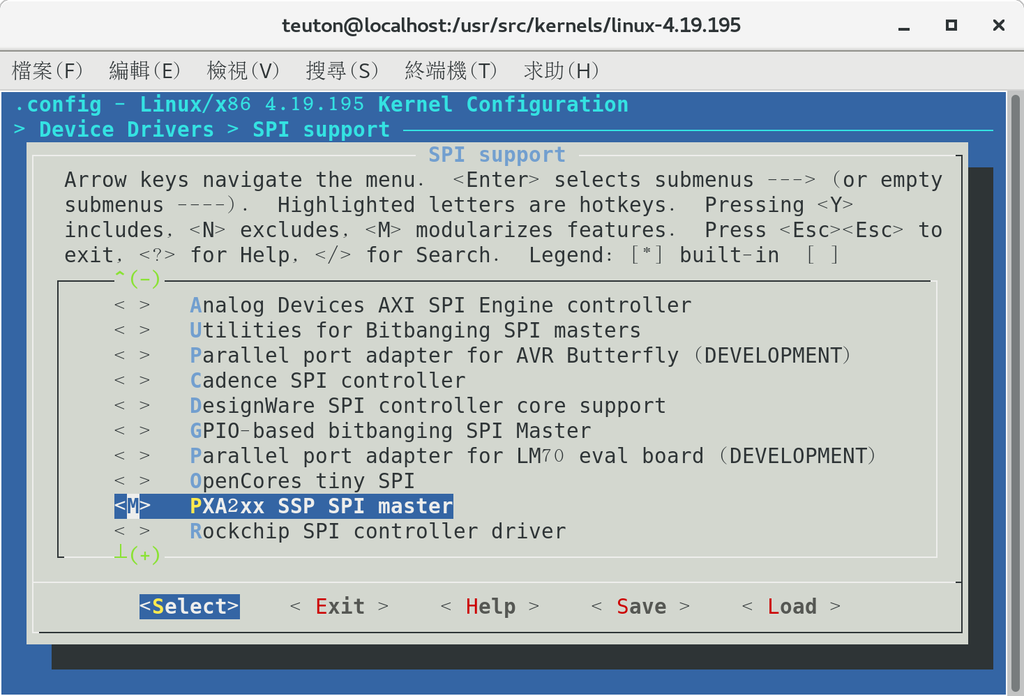

Figure 2.1: 新增 PXA2xx 模組

## 2.4 編譯和安裝核心

執行 `make -j $(nproc)` 就能開始編譯核心，這個步驟大約會花費一個小時，接著執行 `make modules_install` 就能安裝核心模組，完成後再執行 `make install` 進行核心的安裝

安裝完成後，grub 選單預設值會自動更新成新的內核版本，要手動調整預設值可以輸入以下指令

```r
# 指定 grub 選單的預設內核版本
update-initramfs -c -k 4.19.195

# 更新 grub 選單使設定生效
update-grub
```

# 3 mac 配件驅動

以下使用 github 提供的驅動程式來驅動相關 mac 配件，所以需要先安裝 git

```r
apt-get install git
```

## 3.1 macbook 鍵盤驅動

輸入以下指令安裝基本的觸控板與鍵盤驅動

```r
cd /tmp
git clone https://github.com/cb22/macbook12-spi-driver.git
cd macbook12-spi-driver
make
make install
```

重新開機後即可使用 mac 觸控板與鍵盤

## 3.2 mac 觸控板進階驅動

基本 mac 觸控板只支援單擊左鍵和雙指捲動頁面，如果要設定雙擊右鍵等等，你需要安裝進階驅動程式

```r
# 確認 Xorg 為此指令的其中一個輸出後繼續
ps -e | grep X

# 安裝必要套件
apt-get install pkg-config libmtdev-dev mtdev-tools xserver-xorg-dev xutils-dev

# 將你的使用者帳號加入至 input 群組以啟用驅動程式設定
adduser "`whoami`" input

# 進行驅動程式編譯與安裝
cd /tmp
git clone https://github.com/p2rkw/xf86-input-mtrack.git
cd xf86-input-mtrack
./configure --with-xorg-module-dir=/usr/lib/xorg/modules
make
make install

# 建立組態檔
touch /usr/share/X11/xorg.conf.d/50-mtrack.conf

# 開啟文字編輯器進行編輯
edit /usr/share/X11/xorg.conf.d/50-mtrack.conf
```

複製以下文字至 50-mtrack.conf

```r
# Install mtrack driver 0.5.0++
# Save this file to /usr/share/X11/xorg.conf.d/50-mtrack.conf
# This config is specialized for MacBook Air 2012 (5,2)
Section "InputClass"
        MatchIsTouchpad "on"
        Identifier      "Touchpads"
        MatchDevicePath "/dev/input/event*"
        Driver          "mtrack"
        # The faster you move, the more distance pointer will travel, using "polynomial" profile
        Option          "AccelerationProfile" "2"
        # Tweak cursor movement speed with this
        Option          "Sensitivity" "0.05"
        # Pressure at which a finger is detected as a touch
        Option          "FingerHigh" "5"
        # Pressure at which a finger is detected as a release
        Option          "FingerLow" "5"
        # I often use thumb to press down the physical button, so let's not ignore it
        Option          "IgnoreThumb" "false"
        Option          "ThumbRatio" "70"
        Option          "ThumbSize" "25"
        # Ignore palm, with palm takes up to 30% of your touch pad
        Option          "IgnorePalm" "true"
        Option          "PalmSize" "30"
        # Trigger mouse button when tap: 1 finger - left click, 2 finger - right click, 3 - middle click
        Option          "TapButton1" "1"
        Option          "TapButton2" "3"
        Option          "TapButton3" "2"
        Option          "TapButton4" "0"
        Option          "ClickTime" "25"
        # Disable tap-to-drag, we're using three finger drag instead
        Option          "TapDragEnable" "false"
        # While touching the touch pad with # fingers, press the touchpad physical click button
        Option          "ClickFinger1" "1"
        Option          "ClickFinger2" "3"
        Option          "ClickFinger3" "2"
        Option          "ButtonMoveEmulate" "false"
        Option          "ButtonIntegrated" "true"
        # The momentum after scroll fingers released
        Option          "ScrollCoastDuration" "300"
        Option          "ScrollCoastEnableSpeed" ".1"
        # Natural scrolling with two fingers
        Option          "ScrollSmooth" "true"
        Option          "ScrollUpButton" "5"
        Option          "ScrollDownButton" "4"
        Option          "ScrollLeftButton" "7"
        Option          "ScrollRightButton" "6"
        # Tweak scroll sensitivity with ScrollDistance, don't touch ScrollSensitivity
        Option          "ScrollDistance" "250"
        Option          "ScrollClickTime" "10"
        # Three finger drag
        Option          "SwipeDistance" "1"
        Option          "SwipeLeftButton" "1"
        Option          "SwipeRightButton" "1"
        Option          "SwipeUpButton" "1"
        Option          "SwipeDownButton" "1"
        Option          "SwipeClickTime" "0"
        Option          "SwipeSensitivity" "1500"
        # Four finger swipe, 8 & 9 are for browsers navigating back and forth respectively
        Option          "Swipe4LeftButton" "9"
        Option          "Swipe4RightButton" "8"
        # Mouse button >= 10 are not used by Xorg, so we'll map them with xbindkeys and xdotool later
        Option          "Swipe4UpButton" "11"
        Option          "Swipe4DownButton" "10"
        # Mouse buttons triggered by 2-finger pinching gesture
        Option          "ScaleDistance" "300"
        Option          "ScaleUpButton" "12"
        Option          "ScaleDownButton" "13"
        # Mouse buttons trigger by 2-finger rotating gesture, disabled to enhance the pinch gesture
        Option          "RotateLeftButton" "0"
        Option          "RotateRightButton" "0"
EndSection
```

如果你想要了解更多選項，你可以參考[作者的說明](https://github.com/p2rkw/xf86-input-mtrack)

儲存檔案後重開機，觸控板會更貼近 mac 設計

## 3.3 macbook touchbar驅動

輸入以下指令安裝 mac 觸控條驅動，如果複製 git repository 發生錯誤，就將 /tmp 內的 macbook12-spi-driver 刪除後再試一次

```r
cd /tmp
git clone https://github.com/roadrunner2/macbook12-spi-driver.git
cd macbook12-spi-driver
make
make install
```

重新開機後即可使用 mac 觸控條

# 4 參考資料

- [鳥哥的 Linux 私房菜 - 基礎學習篇](https://linux.vbird.org/linux_basic/centos7/)
- [Linux on mid-2017 MacBookPro](https://nixaid.com/linux-on-macbookpro-old/)
- [State of Linux on the MacBook Pro 2016 & 2017](https://github.com/Dunedan/mbp-2016-linux)
- [Debian 參考手冊](https://www.debian.org/doc/manuals/debian-reference/index.zh-tw.html)